# Example 3.1: Meuse data. Direct and cross-semivariograms, linear model of coregionalization

Author

Aritz Adin and Tomás Goicoa

Published

Dec/2026

# 1 Objectives

In this example we will:

- Explore two spatially correlated variables: the concentrations of **lead** (primary variable) and **zinc** (secondary variable) in the Meuse soil samples.
- Compute the **direct semivariograms** of both variables and their **cross-semivariogram**.
- Fit a **linear model of coregionalization**, the joint model required by co-kriging.

**TipR script**

You can download the R script with all the code of this example and follow it step by step in RStudio:

# 2 Packages

```r
library(dplyr)
library(gstat)
library(sf)
```

# 3 Description of the data

**NoteWhy lead?**

Lead (Pb) is a serious human health hazard: it can be inhaled as dust from disturbed soil, or taken up by plants and ingested. As a reference, the Berlin Digital Environmental Atlas establishes the following guide values for lead in soils:

- above 600 mg/kg, grain crops cannot be grown for human consumption;
- above 300 mg/kg, crops must be tested;
- above 100 mg/kg, consumption of leafy vegetables should be avoided;
- below 200 mg/kg is required for sports fields or parks.

Natural levels in unpolluted soils are around 30 mg/kg. In the Meuse data, lead ranges from 37 to 654 mg/kg, and more than half of the samples exceed 100 mg/kg.

The `meuse` dataset (included in the `sp` package) contains 155 soil samples collected in the floodplain of the river Meuse (the Netherlands), with the concentrations of several heavy metals (in ppm, i.e., mg/kg). The coordinates are expressed in the Dutch national grid (EPSG:28992), in metres.

```r
data(meuse, package="sp")        # soil samples
data(meuse.riv, package="sp")    # outline of the river

meuse_sf <- meuse |>
  as_tibble() |>
  st_as_sf(coords=c("x","y"), crs=28992)

river <- list(meuse.riv) |>
  st_polygon() |>
  st_sfc(crs = 28992)

head(meuse_sf)
```

```
Simple feature collection with 6 features and 12 fields
Geometry type: POINT
Dimension:     XY
Bounding box:  xmin: 181025 ymin: 333260 xmax: 181390 ymax: 333611
Projected CRS: Amersfoort / RD New
# A tibble: 6 × 13
  cadmium copper  lead  zinc  elev    dist    om ffreq soil  lime  landuse
    <dbl>  <dbl> <dbl> <dbl> <dbl>   <dbl> <dbl> <fct> <fct> <fct> <fct>
1    11.7     85   299  1022  7.91 0.00136  13.6 1     1     1     Ah
2     8.6     81   277  1141  6.98 0.0122   14   1     1     1     Ah
3     6.5     68   199   640  7.8  0.103    13   1     1     1     Ah
4     2.6     81   116   257  7.66 0.190     8   1     2     0     Ga
5     2.8     48   117   269  7.48 0.277     8.7 1     2     0     Ah
6     3       61   137   281  7.79 0.364     7.8 1     2     0     Ga
# ℹ 2 more variables: dist.m <dbl>, geometry <POINT [m]>
```

```r
head(river)
```

```
Geometry set for 1 feature
Geometry type: POLYGON
Dimension:     XY
Bounding box:  xmin: 178304 ymin: 325698.5 xmax: 182331.5 ymax: 337684.8
Projected CRS: Amersfoort / RD New
```

Both metals come from the same industrial sources and are transported in the same way by the river floods, so we expect them to show a similar spatial pattern:

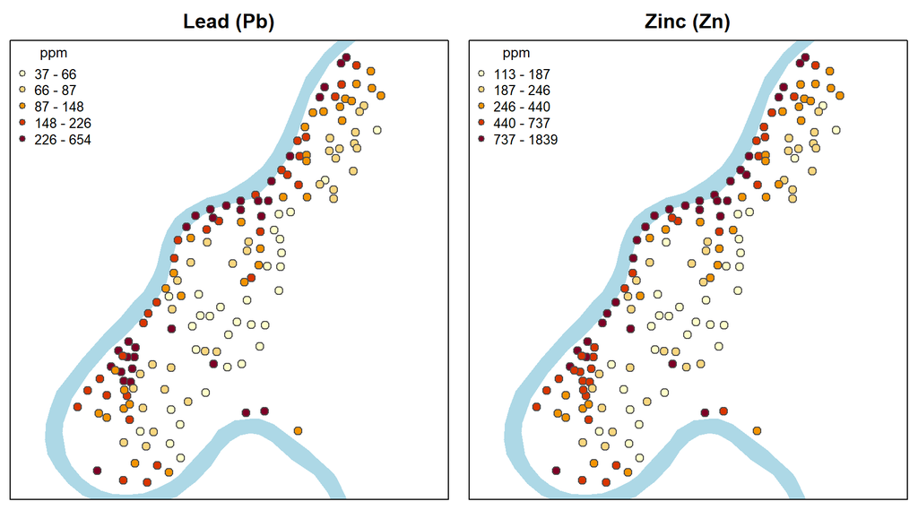

Lead and zinc concentrations (ppm) in the Meuse soil samples, classified by quintiles.

Both maps show the same pattern: higher concentrations near the river and lower concentrations further away from it.

## Log transformation of lead and zinc variables

Heavy metal concentrations usually have very **right-skewed** distributions: many low values and a few very high ones.

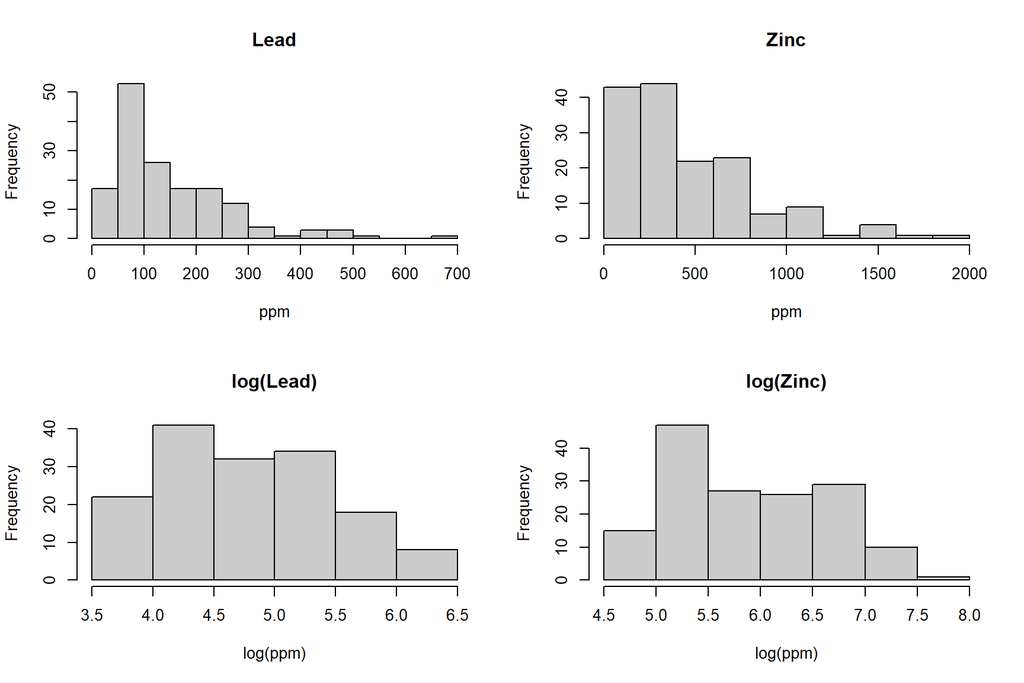

```r
par(mfrow = c(2, 2))
hist(meuse_sf$lead, main = "Lead", xlab = "ppm", col = "grey80")
hist(meuse_sf$zinc, main = "Zinc", xlab = "ppm", col = "grey80")
hist(log(meuse_sf$lead), main = "log(Lead)", xlab = "log(ppm)", col = "grey80")
hist(log(meuse_sf$zinc), main = "log(Zinc)", xlab = "log(ppm)", col = "grey80")
```

We will work with both variables on the **log scale** because:

- The log transformation makes their distributions approximately symmetric.
- The empirical semivariogram is based on squared differences, so it is very sensitive to extreme values. The log transformation stabilizes it.
- Co-kriging is based on linear relationships between the variables, and on the log scale the relationship between lead and zinc is slightly more linear.
- Both variables are on the same scale, which makes the sills of the cross-semivariogram easier to interpret.

**Note**

Predictions obtained on the log scale must be back-transformed with `exp()`. This back-transformation approximately gives the **median**, not the mean, on the original scale.

# 4 Semivariogram of the primary variable

Before working with both variables, we analyse the primary variable (lead) on its own, as in Chapter 1.

## 4.1 Empirical semivariogram

```r
v_lead <- variogram(log(lead) ~ 1, meuse_sf)
v_lead
```

```
    np       dist     gamma dir.hor dir.ver   id
1   57   79.29244 0.1046520       0       0 var1
2  299  163.97367 0.1965929       0       0 var1
3  419  267.36483 0.2507668       0       0 var1
4  457  372.73542 0.3330690       0       0 var1
5  547  478.47670 0.3875716       0       0 var1
6  533  585.34058 0.4817750       0       0 var1
7  574  693.14526 0.5031432       0       0 var1
8  564  796.18365 0.5545787       0       0 var1
9  589  903.14650 0.5693882       0       0 var1
10 543 1011.29177 0.6098806       0       0 var1
11 500 1117.86235 0.6253271       0       0 var1
12 477 1221.32810 0.5126165       0       0 var1
13 452 1329.16407 0.5755737       0       0 var1
14 457 1437.25620 0.4676728       0       0 var1
15 415 1543.20248 0.4804887       0       0 var1
```

- The term `~ 1` in the formula means a **constant mean** (no trend).
- By default, the maximum distance (`cutoff`) is one third of the diagonal of the bounding box of the data, divided into 15 distance lags (`width = cutoff/15`).

*Remember*: each row of the output corresponds to a distance lag

| Column | Meaning | Notation |
| --- | --- | --- |
| `np` | Number of pairs of observations in the lag | $\lvert N(h)\rvert$ |
| `dist` | Mean distance of these pairs (m) | $h$ |
| `gamma` | Empirical semivariance | $\hat\gamma(h)$ |

**NoteInterpretation**

For example, the first row indicates that there are 57 pairs of samples separated by a mean distance of 79 m, with an empirical semivariance of 0.105.

## 4.2 Fitted theoretical model

```r
vgm_lead <- fit.variogram(v_lead, model=vgm(psill=0.5, model="Sph",
                                            range=1000, nugget=0.05))
vgm_lead
```

```
  model      psill    range
1   Nug 0.05156252   0.0000
2   Sph 0.51530678 965.1506
```

The function `vgm()` defines a theoretical model with **initial values** for its parameters (chosen by visual inspection):

| Argument | Meaning | Notation |
| --- | --- | --- |
| `model = "Sph"` | Spherical model | — |
| `psill = 0.5` | Partial sill | $\sigma^2$ |
| `range = 1000` | Range (for the spherical model, the exact range) | $\rho$ |
| `nugget = 0.05` | Nugget effect | $\tau^2$ |

The function `fit.variogram()` then fits the model to the empirical semivariogram by **weighted least squares** (Chapter 2).

**NoteInterpretation of the fitted model**

- Nugget effect: $\tau^2 \approx$ 0.052.
- Partial sill: $\sigma^2 \approx$ 0.515.
- Total sill: $\tau^2+\sigma^2 \approx$ 0.567. The nugget effect represents about 9% of the total sill: the variability at very short distances is small.
- Range: $\rho \approx$ 965 m. Beyond this distance, lead concentrations in two samples are no longer correlated.

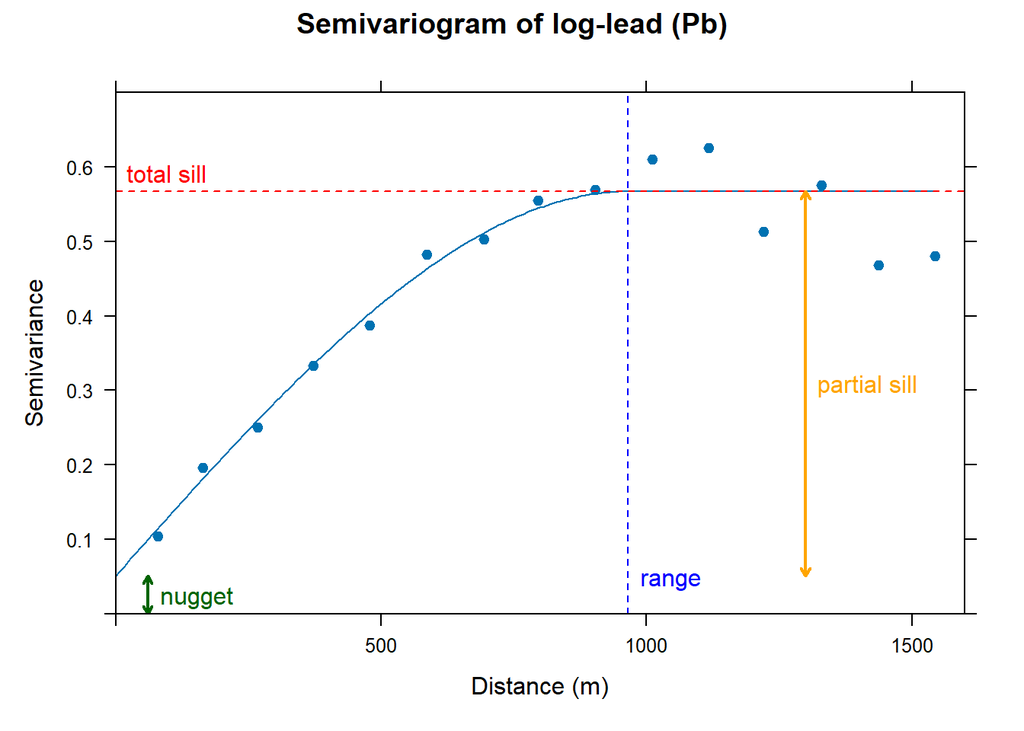

```r
plot(v_lead, vgm_lead, pch = 19,
     xlab = "Distance (m)", ylab = "Semivariance",
     main = "Semivariogram of log-lead (Pb)")
```

# 5 Direct and cross-empirical semivariograms

To work with both variables jointly, we create a `gstat` object containing them:

```r
g <- gstat(NULL, id = "Pb", formula = log(lead) ~ 1, data = meuse_sf)
g <- gstat(g,    id = "Zn", formula = log(zinc) ~ 1, data = meuse_sf)
g
```

```
data:
Pb : formula = log(lead)`~`1 ; data dim = 155 x 12
Zn : formula = log(zinc)`~`1 ; data dim = 155 x 12
```

When `variogram()` is applied to an object with two variables, `gstat` computes the **three empirical semivariograms** at once:

```r
v <- variogram(g)
```

| `id` | Semivariogram | Notation |
| --- | --- | --- |
| `Pb` | Direct semivariogram of lead | $\hat\gamma_{11}(h)$ |
| `Zn` | Direct semivariogram of zinc | $\hat\gamma_{22}(h)$ |
| `Pb.Zn` | Cross-semivariogram | $\hat\gamma_{12}(h)$ |

For the cross-semivariogram, the product of the differences of both variables is used for each pair of locations, instead of the squared difference of a single variable. Therefore, it can only be computed at the locations where both variables have been measured (in the Meuse data, all of them).

**Tip**

- The direct semivariogram of lead (`id = "Pb"`) is exactly the same as `v_lead`, computed in the previous section.
- In the cross-semivariogram, the number of pairs `np` is twice that of the direct semivariograms, because `gstat` counts each pair of locations in both possible orders. This does not affect the value of the semivariance.

```r
v |>
  filter(id=="Pb") |>
  select(np, dist, gamma) |>
  head()
```

```
   np      dist     gamma
1  57  79.29244 0.1046520
2 299 163.97367 0.1965929
3 419 267.36483 0.2507668
4 457 372.73542 0.3330690
5 547 478.47670 0.3875716
6 533 585.34058 0.4817750
```

```r
v |>
  filter(id=="Pb.Zn") |>
  select(np, dist, gamma) |>
  head()
```

```
    np      dist     gamma
1  114  79.29244 0.1043109
2  598 163.97367 0.1971895
3  838 267.36483 0.2620106
4  914 372.73542 0.3559684
5 1094 478.47670 0.4076456
6 1066 585.34058 0.5046648
```

# 6 Linear model of coregionalization

The three semivariograms cannot be fitted separately: the joint model must be valid. In the **linear model of coregionalization**, the three semivariograms share the same basic structures (same shape and same range) and differ only in their sills.

```r
lmc <- fit.lmc(v, g, model=vgm_lead)
lmc$model
```

```
$Pb
  model      psill    range
1   Nug 0.05156252   0.0000
2   Sph 0.51530679 965.1506

$Pb.Zn
  model      psill    range
1   Nug 0.04801059   0.0000
2   Sph 0.54418718 965.1506

$Zn
  model      psill    range
1   Nug 0.05941403   0.0000
2   Sph 0.60031906 965.1506
```

The function `fit.lmc()` takes:

- the empirical semivariograms (`v`);
- the `gstat` object with both variables (`g`);
- the model fitted for lead (`vgm_lead`), from which it takes the **basic structures** (nugget effect + spherical model) and the **range** (965 m).

It keeps the range fixed and fits only the **sills** of each semivariogram. The result is again a `gstat` object, now including the fitted models, which will be used for co-kriging predictions (`predict()`) and cross-validation (`gstat.cv()`).

**Note**

The range is taken from the direct semivariogram of lead, which implicitly assumes that it is also adequate for zinc and for the cross-semivariogram. Looking at the plot below, this assumption is reasonable. Alternatively, `fit.lmc(..., fit.ranges = TRUE)` also refits the common range using the three semivariograms jointly.

## Plot of the fitted model

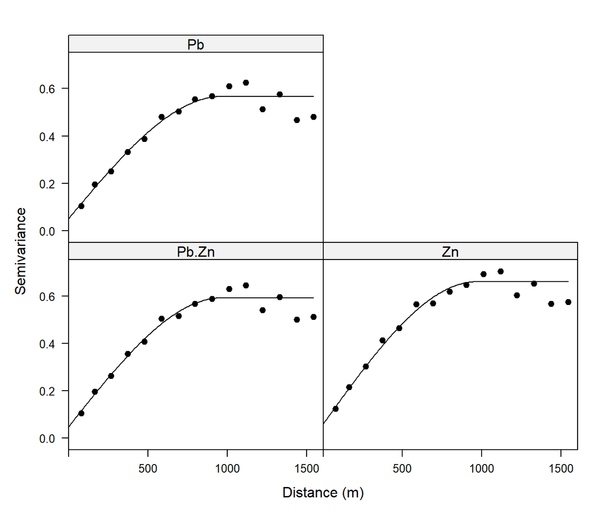

Direct and cross empirical semivariograms of log-lead (Pb) and log-zinc (Zn), with the fitted linear model of coregionalization.

```r
plot(v, lmc, pch = 19, col = "black",
     xlab = "Distance (m)", ylab = "Semivariance",
     scales = list(alternating = 1, tck = c(1, 0)))
```

In each panel, the **points** are the empirical semivariograms (computed with `variogram()`) and the **lines** are the fitted linear model of coregionalization (`fit.lmc()`).

**NoteInterpretation**

The cross-semivariogram shows a clear spatial structure, very similar to that of the direct semivariograms: it increases with distance and levels off at about 0.59. This indicates a **strong spatial correlation** between both metals, so zinc can provide useful information to predict lead in co-kriging.

# 7 Summary of the workflow

| Step | Function | Result |
| --- | --- | --- |
| Empirical semivariogram of the primary variable | `variogram()` | Points |
| Theoretical model of the primary variable | `fit.variogram()` | Line (shape and range) |
| Direct and cross empirical semivariograms | `gstat()` + `variogram()` | Points of the three semivariograms |
| Linear model of coregionalization | `fit.lmc()` | Lines of the three semivariograms (same shape, different sills) |

# 8 Exercise

Repeat the analysis using **organic matter** (`om`) as the secondary variable instead of zinc. Note that:

- `om` has missing values, which must be removed first (`meuse_sf |> filter(!is.na(om))`).
- As in the example, use both variables on the **log scale** (`log(lead)` and `log(om)`).

Answer the following questions:

- Is the cross-semivariogram between lead and organic matter structured?
- How does it compare with the cross-semivariogram between lead and zinc?

## Solution

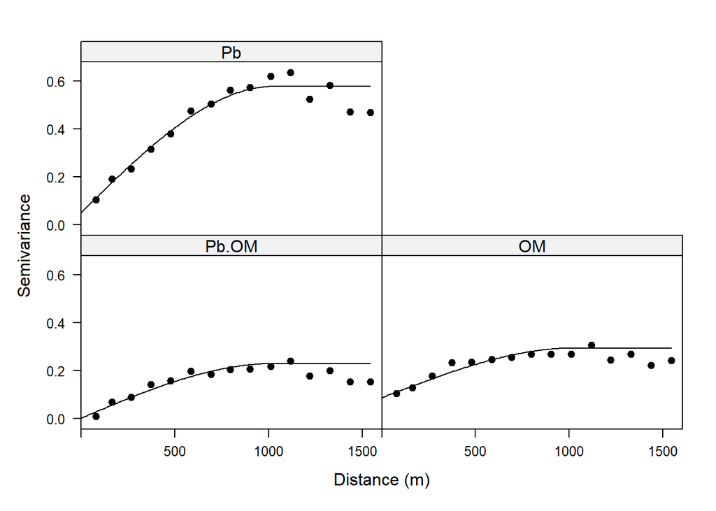

Table 1: Comparison of the linear models of coregionalization for lead and zinc (example) and lead and organic matter (exercise).

|  | Example (Pb and Zn) | Exercise (Pb and OM) |
| --- | --- | --- |
| Number of samples | 155 | 153 |
| Correlation at the same sampling points (log scale) | 0.97 | 0.53 |
| Common range | $\approx$ 965 m | $\approx$ 1028 m |
| Cross-semivariogram sill: nugget effect | 0.048 | 0.002 |
| Cross-semivariogram sill: spherical model | 0.544 | 0.227 |
| Total sill of the cross-semivariogram | $\approx$ 0.59 | $\approx$ 0.23 |

**Interpretation:**

- The cross-semivariogram between lead and organic matter **is structured**: it increases with distance and levels off, so there is a spatial correlation between both variables.
- However, this correlation is **considerably weaker** than with zinc (Table 1): the sill of the cross-semivariogram is much lower ($0.23$ vs. $0.59$), and the correlation at the same sampling points is also lower ($0.53$ vs. $0.97$). For the nugget effect component, the cross-semivariogram sill is almost zero: at very short distances, the variations of both variables are practically independent.
- **Conclusion for co-kriging:** zinc is a much better secondary variable to predict lead. Organic matter could provide some information, but less.